# Summer Lab 3

Dylan Francisco

July 14, 2023

# Lab 3a: Relational Data

## Introduction

The main purpose of this lab is to practice data join skills from Chapter 10. The functions and their purposes are listed as follows:

- `inner_join()` Keeps observations appear in both datasets.
- `left_join()` Keeps all observations in left dataset.
- `right_join()` Keeps all observations in right dataset.
- `full_join()` Keeps all observations in both datasets.
- `semi_join()` Keeps all observations in left dataset that have a match in right dataset.
- `anti_join()1` Drops all observations in left dataset that have a match in right dataset.

You will need to modify the code chunks so that the code works within each of chunk (usually this means modifying anything in ALL CAPS). You will also need to modify the code outside the code chunk. When you get the desired result for each step, change `Eval=F` to `Eval=T` and knit the document to HTML to make sure it works. After you complete the lab, you should submit your HTML file of what you have completed to Canvas before the deadline.

## Part 1

In part 1, you will practice the skills using the datasets from the R package `Lahman`. This database includes data related to baseball teams. It includes summary statistics about how the players performed on offense and defense for several years. It also includes personal information about the players.

The `Batting` data frame contains the offensive statistics for all players for many years. You can see, for example, the top 10 hitters in 2016 by running this code: (For more details of the dataset run `?Batting` in console.)

```r
top <- Batting %>%
  filter(yearID == 2016) %>%
  arrange(desc(HR)) %>%
  slice(1:10)

top #Do Not Remove
```

```
##     playerID yearID stint teamID lgID   G  AB   R   H X2B X3B HR RBI SB CS BB
## 1  trumbma01   2016     1    BAL   AL 159 613  94 157  27   1 47 108  2  0 51
## 2   cruzne02   2016     1    SEA   AL 155 589  96 169  27   1 43 105  2  0 62
## 3  daviskh01   2016     1    OAK   AL 150 555  85 137  24   2 42 102  1  2 42
## 4  doziebr01   2016     1    MIN   AL 155 615 104 165  35   5 42  99 18  2 61
## 5  encared01   2016     1    TOR   AL 160 601  99 158  34   0 42 127  2  0 87
## 6  arenano01   2016     1    COL   NL 160 618 116 182  35   6 41 133  2  3 68
## 7  cartech02   2016     1    MIL   NL 160 549  84 122  27   1 41  94  3  1 76
## 8  frazito01   2016     1    CHA   AL 158 590  89 133  21   0 40  98 15  5 64
## 9  bryankr01   2016     1    CHN   NL 155 603 121 176  35   3 39 102  8  5 75
## 10  canoro01   2016     1    SEA   AL 161 655 107 195  33   2 39 103  0  1 47
##     SO IBB HBP SH SF GIDP
## 1  170   1   3  0  0   14
## 2  159   5   9  0  7   15
## 3  166   0   8  0  5   19
## 4  138   6   8  2  5   12
## 5  138   3   5  0  8   22
## 6  103  10   2  0  8   17
## 7  206   1   9  0 10   18
## 8  163   1   4  1  7   11
## 9  154   5  18  0  3    3
## 10 100   8   8  0  5   18
```

But who are these players? We see an ID, but not the names. The player names are in this table named `People`.

```r
head(People,5)
```

```
##    playerID birthYear birthMonth birthDay birthCountry birthState  birthCity
## 1 aardsda01      1981         12       27          USA         CO     Denver
## 2 aaronha01      1934          2        5          USA         AL     Mobile
## 3 aaronto01      1939          8        5          USA         AL     Mobile
## 4  aasedo01      1954          9        8          USA         CA     Orange
## 5  abadan01      1972          8       25          USA         FL Palm Beach
##   deathYear deathMonth deathDay deathCountry deathState deathCity nameFirst
## 1        NA         NA       NA         <NA>       <NA>      <NA>     David
## 2      2021          1       22          USA         GA   Atlanta      Hank
## 3      1984          8       16          USA         GA   Atlanta    Tommie
## 4        NA         NA       NA         <NA>       <NA>      <NA>       Don
## 5        NA         NA       NA         <NA>       <NA>      <NA>      Andy
##   nameLast      nameGiven weight height bats throws      debut  finalGame
## 1  Aardsma    David Allan    215     75    R      R 2004-04-06 2015-08-23
## 2    Aaron    Henry Louis    180     72    R      R 1954-04-13 1976-10-03
## 3    Aaron     Tommie Lee    190     75    R      R 1962-04-10 1971-09-26
## 4     Aase Donald William    190     75    R      R 1977-07-26 1990-10-03
## 5     Abad  Fausto Andres    184     73    L      L 2001-09-10 2006-04-13
##    retroID   bbrefID  deathDate  birthDate
## 1 aardd001 aardsda01       <NA> 1981-12-27
## 2 aaroh101 aaronha01 2021-01-22 1934-02-05
## 3 aarot101 aaronto01 1984-08-16 1939-08-05
## 4 aased001  aasedo01       <NA> 1954-09-08
## 5 abada001  abadan01       <NA> 1972-08-25
```

We can see column names `nameFirst` and `nameLast` in table `People`.

### 1.1 (1 Point)

Use the `left_join` function to create a data frame called `top1`, which contains information of the 10 top home run hitters. The table should have the following columns: `playerID`, `nameFirst`, `nameLast`, and number of home runs (`HR`).

```r
top1 <- top %>%
  left_join(People, by = "playerID") %>%
  select(playerID, nameFirst, nameLast, HR)


top1 #Do Not Remove
```

```
##     playerID nameFirst    nameLast HR
## 1  trumbma01      Mark      Trumbo 47
## 2   cruzne02    Nelson        Cruz 43
## 3  daviskh01     Khris       Davis 42
## 4  doziebr01     Brian      Dozier 42
## 5  encared01     Edwin Encarnacion 42
## 6  arenano01     Nolan     Arenado 41
## 7  cartech02     Chris      Carter 41
## 8  frazito01      Todd     Frazier 40
## 9  bryankr01      Kris      Bryant 39
## 10  canoro01  Robinson        Cano 39
```

### 1.2 (2 Points)

Data `Salaries` contains the baseball player salary data.

```r
head(Salaries,5)
```

```
##   yearID teamID lgID  playerID salary
## 1   1985    ATL   NL barkele01 870000
## 2   1985    ATL   NL bedrost01 550000
## 3   1985    ATL   NL benedbr01 545000
## 4   1985    ATL   NL  campri01 633333
## 5   1985    ATL   NL ceronri01 625000
```

You may be curious about the salaries of the top 10 hitters in 2016:

- Now create a new data frame called `top2` by adding top 10 hitters’ salaries to `top1` and including only `nameFirst`, `nameLast`, `teamID`, `HR`, and `salary` columns.
- Rename the columns to `FirstName`, `LastName`, `Team`, `Homeruns` and `Salary` respectively.
- Arrange the data frame by `Salary` in descending order.

Note that salaries are different every year so make sure to filter for the year 2016. This time, only use `right_join` to complete the exercise.

```r
top2 <- Salaries %>%
  filter(yearID == 2016) %>%
  right_join(top1, by = "playerID") %>%
  select(FirstName = nameFirst,
         LastName = nameLast,
         Team = teamID,
         Homeruns = HR,
         Salary = salary) %>%
  arrange(desc(Salary))

top2   #Do Not Remove
```

```
##    FirstName    LastName Team Homeruns   Salary
## 1   Robinson        Cano  SEA       39 24000000
## 2     Nelson        Cruz  SEA       43 14250000
## 3      Edwin Encarnacion  TOR       42 10000000
## 4       Mark      Trumbo  BAL       47  9150000
## 5       Todd     Frazier  CHA       40  8250000
## 6      Nolan     Arenado  COL       41  5000000
## 7      Brian      Dozier  MIN       42  3000000
## 8      Chris      Carter  MIL       41  2500000
## 9       Kris      Bryant  CHN       39   652000
## 10     Khris       Davis  OAK       42   524500
```

## Part 2

In this part, we will explore relational data from `nycflights13`, which contains four data frames related to the `flights` table that you used in previous assignments.

### 2.1 (2 Points)

Data `airports` gives information about each airport, such as latitude and longitude, identified by the `faa` airport code.

```r
head(airports,5)
```

```
## # A tibble: 5 × 8
##   faa   name                            lat   lon   alt    tz dst   tzone
##   <chr> <chr>                         <dbl> <dbl> <dbl> <dbl> <chr> <chr>
## 1 04G   Lansdowne Airport              41.1 -80.6  1044    -5 A     America/New…
## 2 06A   Moton Field Municipal Airport  32.5 -85.7   264    -6 A     America/Chi…
## 3 06C   Schaumburg Regional            42.0 -88.1   801    -6 A     America/Chi…
## 4 06N   Randall Airport                41.4 -74.4   523    -5 A     America/New…
## 5 09J   Jekyll Island Airport          31.1 -81.4    11    -5 A     America/New…
```

Based on `flights`, compute the average arrival delay by destination (`dest`) and ignore missing values, then join on the `airports` data frame. Only use an inner join.

```r
delay = flights %>%
  group_by(dest) %>%
  summarise(avg_arr_delay=mean(arr_delay, na.rm = TRUE),.groups='drop') %>%
  inner_join(airports, by = c("dest" = "faa")) %>%
  select(everything())

delay #Do Not Remove
```

```
## # A tibble: 101 × 9
##    dest  avg_arr_delay name                   lat    lon   alt    tz dst   tzone
##    <chr>         <dbl> <chr>                <dbl>  <dbl> <dbl> <dbl> <chr> <chr>
##  1 ABQ            4.38 Albuquerque Interna…  35.0 -107.   5355    -7 A     Amer…
##  2 ACK            4.85 Nantucket Mem         41.3  -70.1    48    -5 A     Amer…
##  3 ALB           14.4  Albany Intl           42.7  -73.8   285    -5 A     Amer…
##  4 ANC           -2.5  Ted Stevens Anchora…  61.2 -150.    152    -9 A     Amer…
##  5 ATL           11.3  Hartsfield Jackson …  33.6  -84.4  1026    -5 A     Amer…
##  6 AUS            6.02 Austin Bergstrom In…  30.2  -97.7   542    -6 A     Amer…
##  7 AVL            8.00 Asheville Regional …  35.4  -82.5  2165    -5 A     Amer…
##  8 BDL            7.05 Bradley Intl          41.9  -72.7   173    -5 A     Amer…
##  9 BGR            8.03 Bangor Intl           44.8  -68.8   192    -5 A     Amer…
## 10 BHM           16.9  Birmingham Intl       33.6  -86.8   644    -6 A     Amer…
## # ℹ 91 more rows
```

### 2.2 (1 Points)

Draw a scatterplot with dots representing destination locations and colors of dots representing average arrival delay on US map. We do this to look at the spatial distribution of average arrival delay.

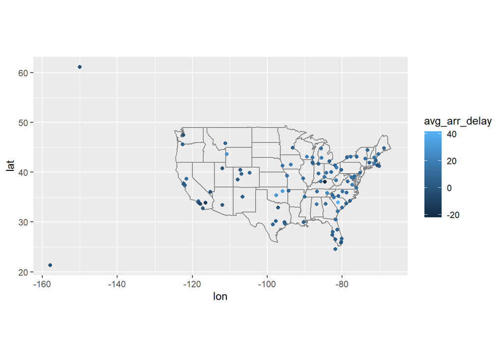

```r
delay %>%
  ggplot(aes(x = lon, y = lat, color = avg_arr_delay)) +
    borders("state") +
    geom_point() +
    coord_quickmap()
```

### 2.3 (1 Points)

Data `planes` gives information about each plane, identified by its `tailnum`. Note that `year` column in `planes` represents the year a plane was manufactured, which is different from `year` column in `flights`.

```r
head(planes,5)
```

```
## # A tibble: 5 × 9
##   tailnum  year type               manufacturer model engines seats speed engine
##   <chr>   <int> <chr>              <chr>        <chr>   <int> <int> <int> <chr>
## 1 N10156   2004 Fixed wing multi … EMBRAER      EMB-…       2    55    NA Turbo…
## 2 N102UW   1998 Fixed wing multi … AIRBUS INDU… A320…       2   182    NA Turbo…
## 3 N103US   1999 Fixed wing multi … AIRBUS INDU… A320…       2   182    NA Turbo…
## 4 N104UW   1999 Fixed wing multi … AIRBUS INDU… A320…       2   182    NA Turbo…
## 5 N10575   2002 Fixed wing multi … EMBRAER      EMB-…       2    55    NA Turbo…
```

Use the `planes` data to calculate the `age` of planes, assuming current year is 2013. Keep only `tailnum` and `age` in the output table `plane_ages`.

```r
plane_ages <-
  planes %>%
  mutate(age = 2013 - year) %>%
  select(tailnum, age)
plane_ages #Do Not Change
```

```
## # A tibble: 3,322 × 2
##    tailnum   age
##    <chr>   <dbl>
##  1 N10156      9
##  2 N102UW     15
##  3 N103US     14
##  4 N104UW     14
##  5 N10575     11
##  6 N105UW     14
##  7 N107US     14
##  8 N108UW     14
##  9 N109UW     14
## 10 N110UW     14
## # ℹ 3,312 more rows
```

### 2.4 (2 Points)

Is there a relationship between the age of a plane and its delays?

- Join the `plane_ages` with `flights`, keeping observations with matches in both datasets.
- Summarize the average departure delay by plane `age` and ignore missing values.
- Draw a scatterplot of plane age vs. average departure delay.

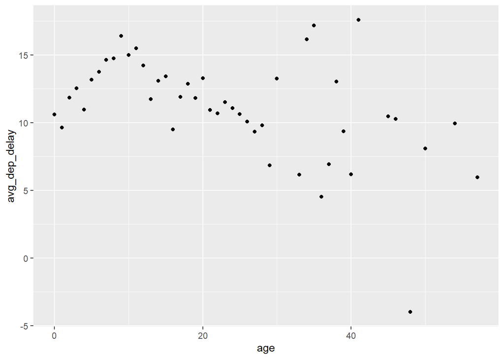

```r
flights %>%
  inner_join(plane_ages, by = "tailnum") %>%
  group_by(age) %>%
  summarise(avg_dep_delay = mean(dep_delay, na.rm = TRUE), .groups='drop') %>%
  ggplot(aes(x = age, y = avg_dep_delay)) +
  geom_point()
```

### 2.5 (0.5 Points)

What does it mean for a flight to have a missing `tailnum`?

```r
flights %>%
  filter(is.na(tailnum))
```

```
## # A tibble: 2,512 × 19
##     year month   day dep_time sched_dep_time dep_delay arr_time sched_arr_time
##    <int> <int> <int>    <int>          <int>     <dbl>    <int>          <int>
##  1  2013     1     2       NA           1545        NA       NA           1910
##  2  2013     1     2       NA           1601        NA       NA           1735
##  3  2013     1     3       NA            857        NA       NA           1209
##  4  2013     1     3       NA            645        NA       NA            952
##  5  2013     1     4       NA            845        NA       NA           1015
##  6  2013     1     4       NA           1830        NA       NA           2044
##  7  2013     1     5       NA            840        NA       NA           1001
##  8  2013     1     7       NA            820        NA       NA            958
##  9  2013     1     8       NA           1645        NA       NA           1838
## 10  2013     1     9       NA            755        NA       NA           1012
## # ℹ 2,502 more rows
## # ℹ 11 more variables: arr_delay <dbl>, carrier <chr>, flight <int>,
## #   tailnum <chr>, origin <chr>, dest <chr>, air_time <dbl>, distance <dbl>,
## #   hour <dbl>, minute <dbl>, time_hour <dttm>
```

Answer: It seems like the flights that are missing tailnums are either decomissioned or never took off, based off of the missing dep_time and arr_time.

### 2.6 (0.5 Points)

What do the tail numbers that don’t have a matching record in planes have in common? (Hint: one variable explains ~90% of the problems. Check the documentation of `planes` for help.)

```r
flights %>%
  anti_join(planes,by="tailnum") %>%
  count(carrier) %>%
  arrange(desc(n))
```

```
## # A tibble: 10 × 2
##    carrier     n
##    <chr>   <int>
##  1 MQ      25397
##  2 AA      22558
##  3 UA       1693
##  4 9E       1044
##  5 B6        830
##  6 US        699
##  7 FL        187
##  8 DL        110
##  9 F9         50
## 10 WN         38
```

Answer: The tail numbers that don’t have a matching record in planes are almost all either American Airways or Envoy Air. This is because these airways report fleet numbers instead of a tail number.

# Lab 3b: Building a Graphic

## Introduction

In this lab, we will slowly construct the image below via `ggplot`. This chart was created using the `presidentialElections` dataset in the `pscl` package. These plots visually compare the historical change in the Democratic Vote between the former Confederate states and non-Confederate states.

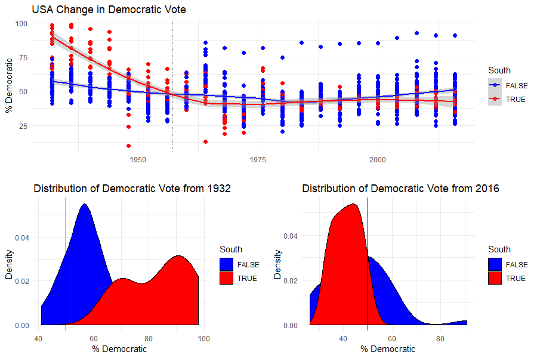

You will need to modify the code chunks so that the code works within each of chunk. When you get the desired result for each step, change `eval=F` to `eval=T` and knit the document to HTML to make sure it works. Do not work out of order or skip around. After you complete the lab or by the end of class, you should submit your HTML file of what you have completed to Canvas.

For ease, we start by reassigning the dataset `presidentialElections` to a new variable called `PE`.

```r
PE=presidentialElections
```

## Part 1: Time Series Plot

### 1.1: Initiate Plot and Print (0 Points)

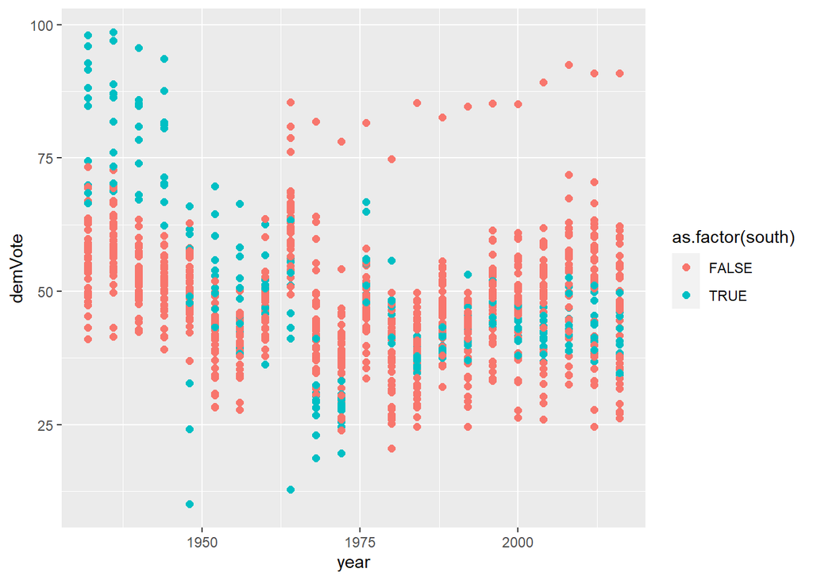

```r
p1<-ggplot(data=PE) +
  geom_point(aes(x=year,y=demVote,color=as.factor(south)),size=2)
p1
```

### 1.2: Modify the Title and Labels (0 Points)

Use `xlab()`, `ylab()`, and `ggtitle()`.

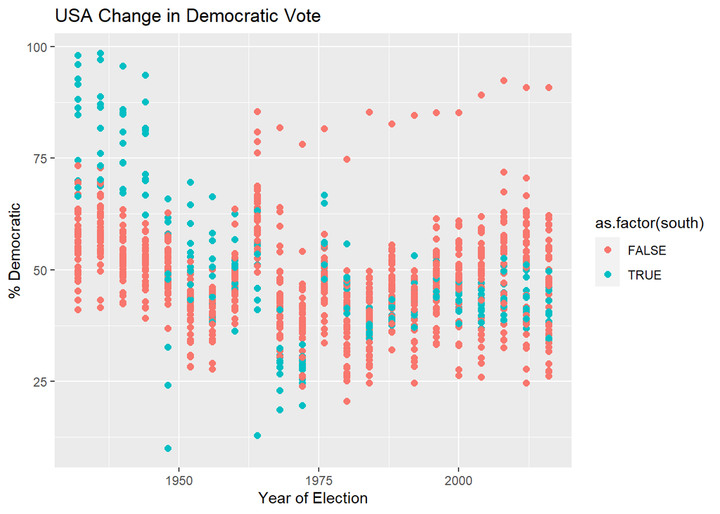

```r
p2<-p1+xlab("Year of Election")+ylab("% Democratic")+ggtitle("USA Change in Democratic Vote")
p2
```

### 1.3: Get Smooth Curves and Print (1 Point)

Use `geom_smooth` similarly how we used `geom_point`.

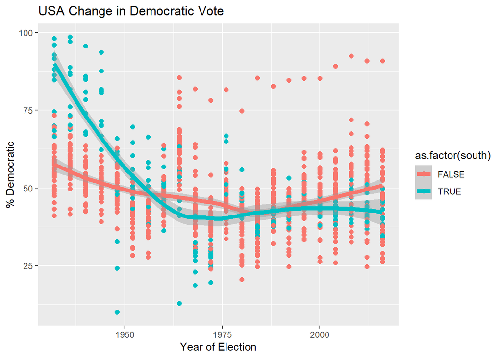

```r
p3<-p2+geom_smooth(aes(x=year,y=demVote,color=as.factor(south)),size=2)
p3
```

### 1.4: Modify the Legend Title and Print (0.5 Points)

Since the legend is for the color aesthetic we use `guides(color=guide_legend(title=COMPLETE_INSIDE))` to rename the legend.

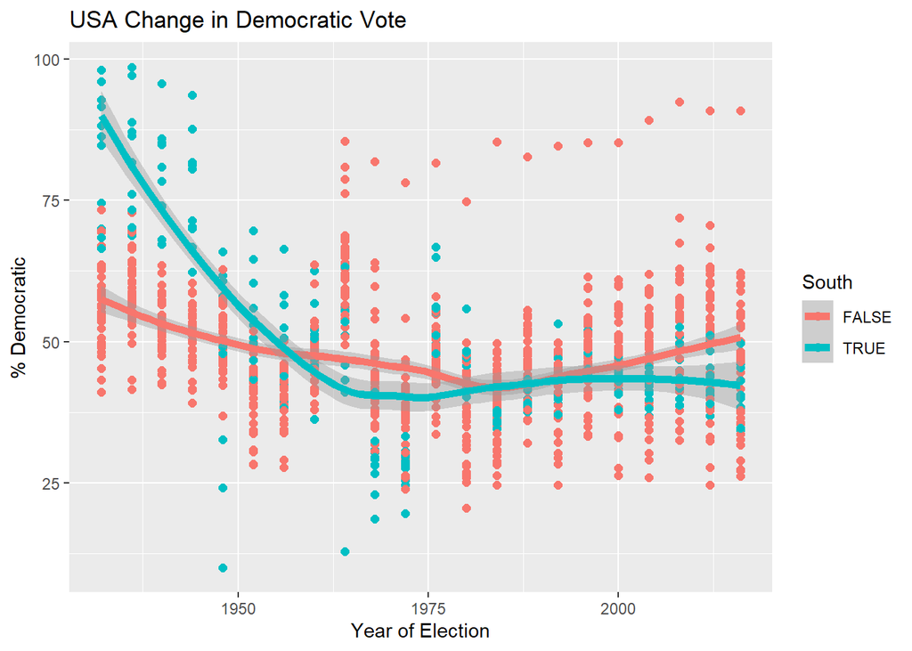

```r
p4<-p3+ guides(color=guide_legend(title="South"))
p4
```

### 1.5: Manually Select the Colors and Print (1 Point)

For the color aesthetic, we want to manually select the two different colors.

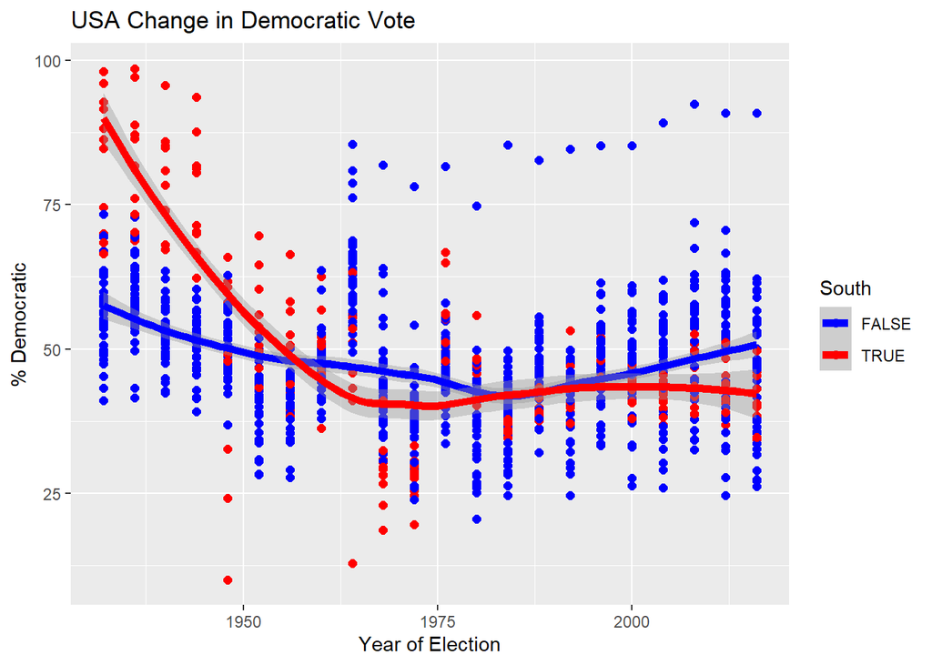

```r
p5<-p4+ scale_color_manual(values=c("Blue","Red"))
p5
```

### 1.6: Reference Line and Print (1 Point)

It doesn’t seem to be until around 1957 where the non-Confederate states began to exceed the former Confederacy on approval for the Democratic party. We want to create a vertical line through the x-axis at 1957 using `geom_vline`. Check `?geom_vline` for more information about this geometric object.

For the color aesthetic, we want to manually select the two different colors.

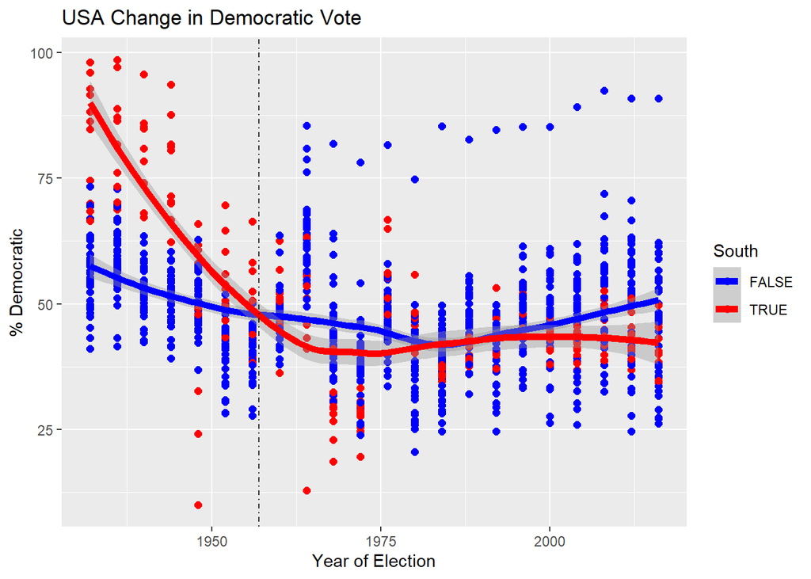

```r
p6<-p5+geom_vline(xintercept = 1957,alpha=0.8,linetype=4)
p6
```

### 1.7: Modify the Theme and Print (0.5 Points)

Use `theme_minimal()` for the plot.

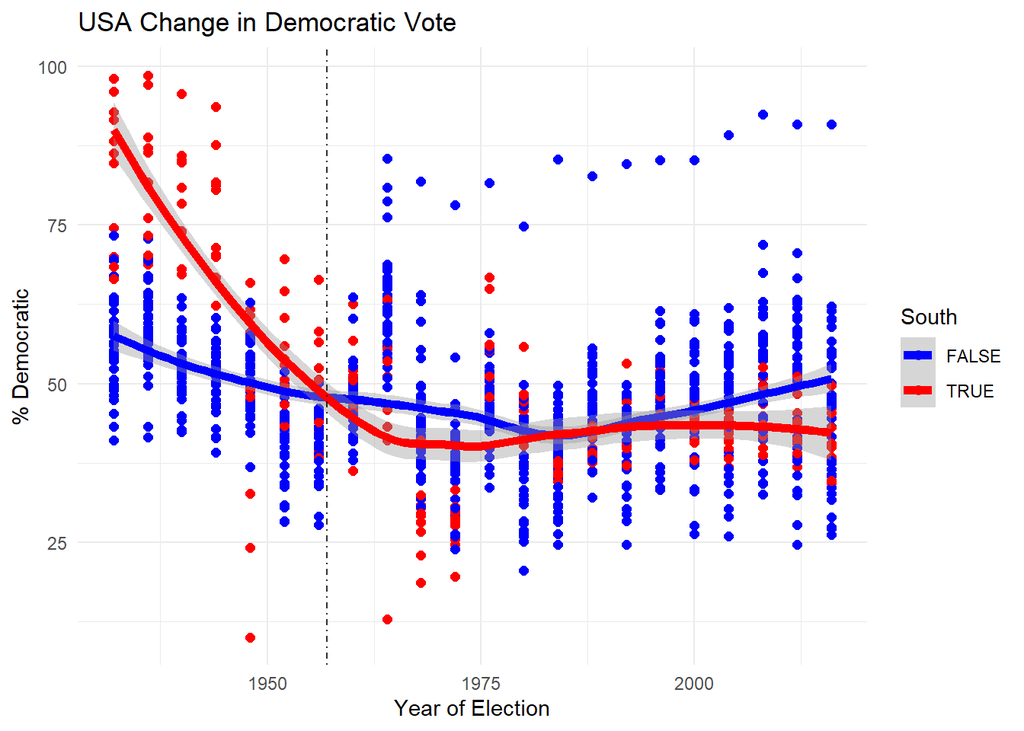

```r
FINALPLOT1<- p6 +
  theme_minimal()
FINALPLOT1
```

## Part 2: Overlapping Density Curves in 1932 and 2016

### 2.1: Create Basic Density Plot (0 Points)

`PE$year` is a vector of all the years represented in the data for all states. `PE$year==1932`creates a vector of `TRUE` and `FALSE` where `TRUE` indicates observations from the year 1932. `PE[PE$year==1932,]` modifies the dataset to only include the data for the year 1932.

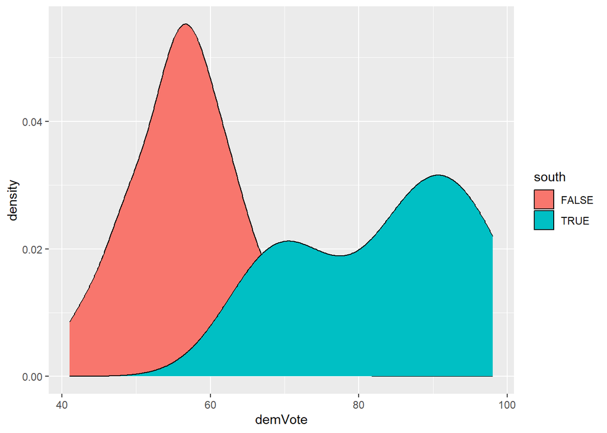

```r
p1<-ggplot(data=PE[PE$year==1932,]) +
      geom_density(aes(x=demVote,fill=south))
p1
```

### 2.2: Modify Plot and Print (2 Points)

Modify the legend, titles, color, theme similarly to how we did the first plot. Also, add a vertical line at 50 which indicates the transition to a majority vote.

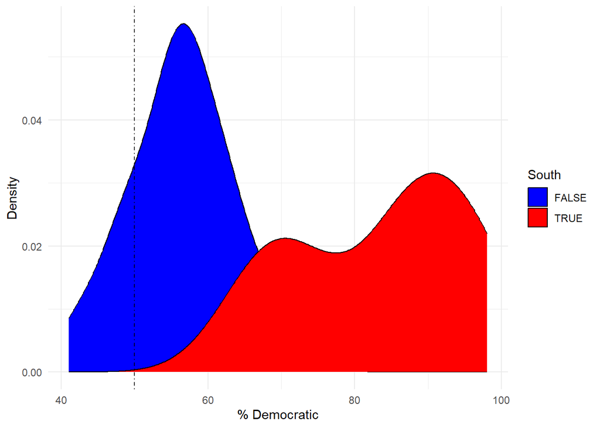

```r
FINALPLOT2<-p1 + xlab("% Democratic") + ylab("Density") +
  scale_fill_manual(values=c("Blue","Red")) +
  geom_vline(xintercept = 50,alpha=0.8,linetype=4) +
  labs(fill = "South") +
  theme_minimal()
FINALPLOT2
```

### 2.3: Overlapping Density Curves in 2016 (2 Points)

Repeat the code that created **FINALPLOT2** for the year 2016. I advise copy and paste.

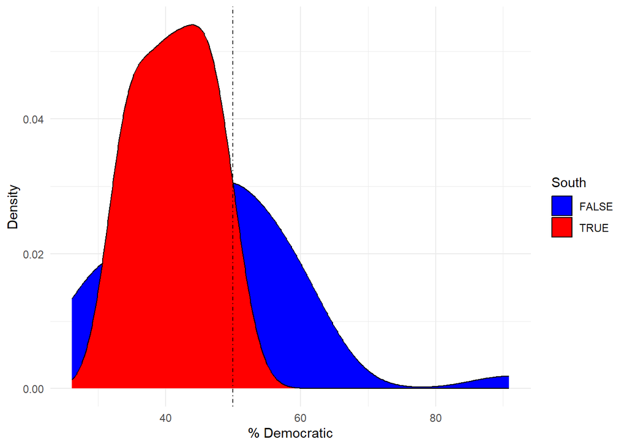

```r
p2<-ggplot(data=PE[PE$year==2016,]) +
      geom_density(aes(x=demVote,fill=south))
FINALPLOT3<- p2 + xlab("% Democratic") + ylab("Density") +
  scale_fill_manual(values=c("Blue","Red")) +
  geom_vline(xintercept = 50,alpha=0.8,linetype=4) +
  labs(fill = "South") +
  theme_minimal()
FINALPLOT3
```

## Part 3: Arrange All Plots in a Pleasant Layout

### 3.1: Arrange Images Into Grid (2 Points)

The `grid.arrange()` function from the `gridExtra` package allows us to do this. This needs to be done after all three plots are created. See if you can figure out what is going on. After knitting the document and observing the picture, change the code chunk option `fig.width=4` to `fig.width=8` and see what happens.

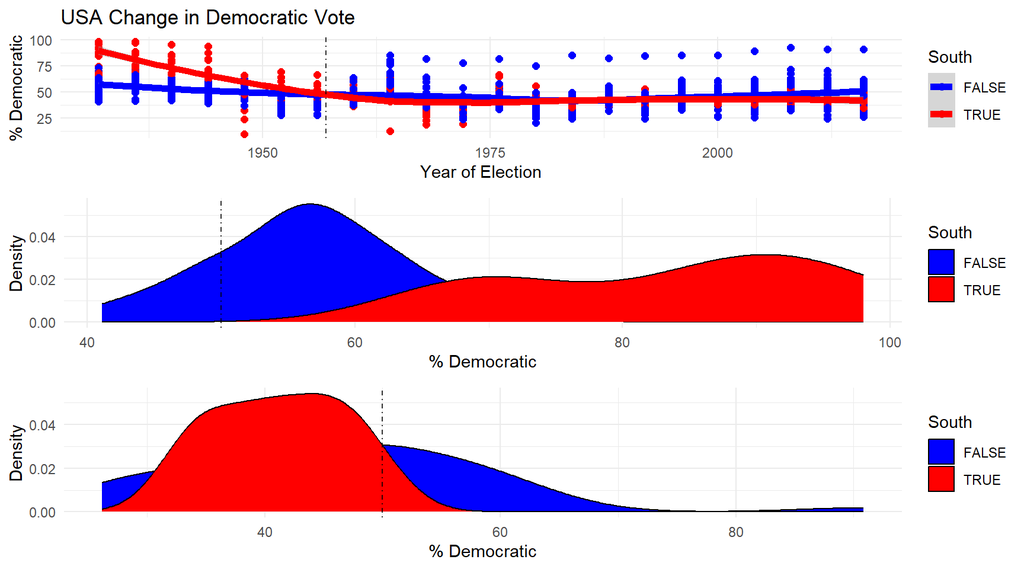

```r
#First Examine this Code and See What Happens

#Defaults to 1 Column Layout and Stacks Plots
grid.arrange(FINALPLOT1,FINALPLOT2,FINALPLOT3)
```

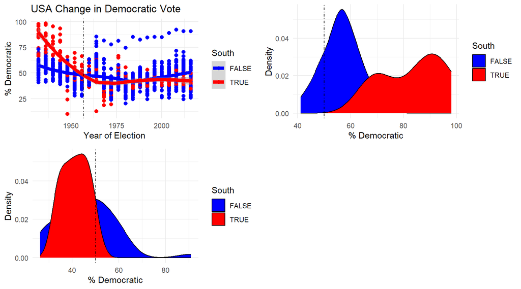

```r
#Starts Placing Plots in a Two Column Layout
grid.arrange(FINALPLOT1,FINALPLOT2,FINALPLOT3,ncol=2)
```

```r
#Now Check this Code Out: Try to Understand how the Matrix is Created and How the Layout is Controlled by the Matrix. Modify It to Get What I created
matrix(c(1,1,2,3),ncol=2)
```

```
##      [,1] [,2]
## [1,]    1    2
## [2,]    1    3
```

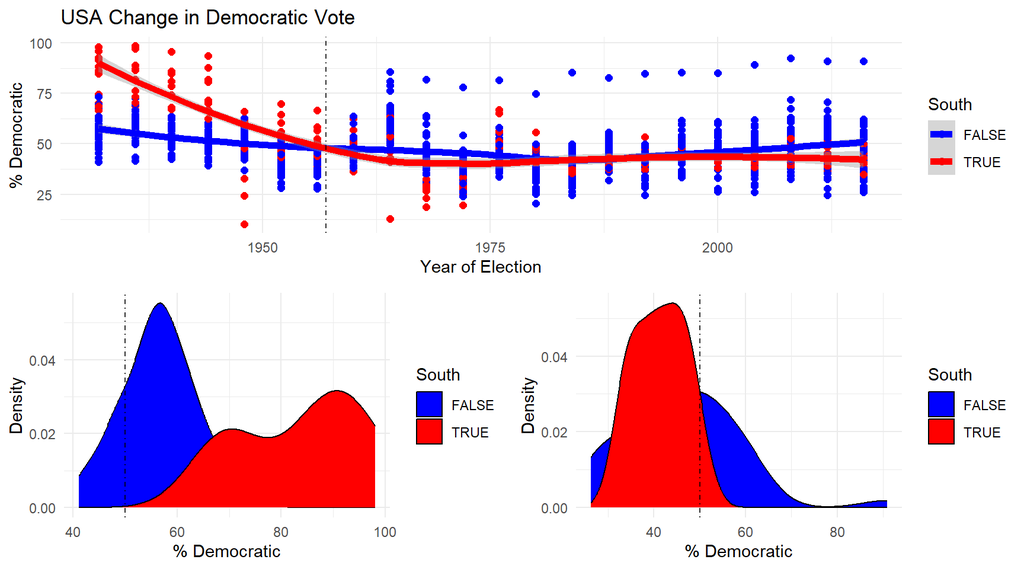

```r
LAYOUT=matrix(c(1, 2, 1, 3),ncol=2)
grid.arrange(FINALPLOT1,FINALPLOT2,FINALPLOT3,layout_matrix=LAYOUT)
```